# task2

Logan Kozal

3/8/2021

Data: Global wild fish catch and aquaculture production, compiled by Earth Policy Institute with 1950-2010 from U.N. Food and Agriculture Organization (FAO), Global Capture Production and Global Aquaculture Production, electronic databases, at www.fao.org/fishery/topic/16140/en.

## Read in data

```r
catch <- read_csv(here::here("data","fish_catch.csv"), skip=2) %>%
  clean_names() %>%
  rename(wild_catch_million_tons = "wild_catch") %>%
  mutate(wild_catch_million_tons = as.numeric(wild_catch_million_tons))
catch <- catch[-c(1:2), ]
catch <- catch[-c(64:67), ]

catch_ts <- catch %>%
  mutate(year = as.Date(year, format = "%Y" )) %>%
  mutate(year = lubridate::year(year)) %>%
  as_tsibble(key = NULL, index = year)
```

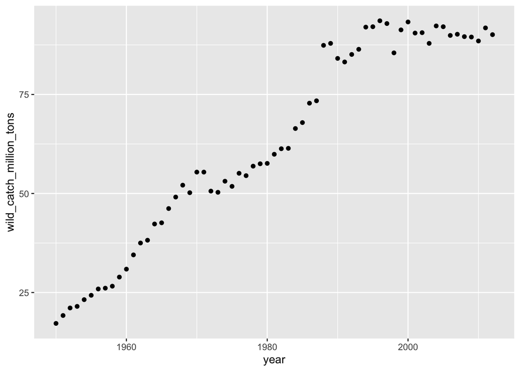

```r
ggplot(catch_ts, aes(x=year, y=wild_catch_million_tons))+
  geom_point()
```

This looks like logistic growth because it levels off at some maximum value at the top. The growth looks pretty linear up to 1987 then levels off. So the equation for catch would be: $C(t)=\frac{K}{1+Ae^{-kt}}$

- $K$ is the maximum value
- $A$ is $\frac{K-C_0}{C_0}$
- $k$ is the growth rate constant

## Find intitial estimates of parameters

Visually the max value, K, looks to be about ~90, we have to estimate k and A

```r
# convert years to a count starting at 0
catch_mod <- catch_ts %>%
  mutate(
    year = year-1950
  )

# Pull out pre-1987 (37 years) and log transform the population to estimate k, this doesnt actually look very exponential but I don't know what other distribution this could be

catch_exp <- catch_mod %>%
  filter(year <= 37) %>%
  mutate(ln_catch = log(wild_catch_million_tons))

# Find the slope of the linear equation to estimate of the growth rate constant, k
lm_k <- lm(ln_catch ~ catch_exp$year, data = catch_exp)
lm_k
```

```
##
## Call:
## lm(formula = ln_catch ~ catch_exp$year, data = catch_exp)
##
## Coefficients:
##    (Intercept)  catch_exp$year
##        3.08173         0.03543
```

```r
# Growth rate k ~ 0.035
```

So to get an estimate for A we can use the formula $A = \frac{K-C_0}{C_0}$ $C_0$ is 17.2 so $A = \frac{90-17.2}{17.2}$

So we can use these as our starting estimates: K ~ 90 A ~ 4.23 k ~ 0.035

and iterate from there

```r
catch_nls <- nls(wild_catch_million_tons ~ K/(1 + A*exp(-k*year)),
              data = catch_mod,
              start = list(K = 90, A = 4.23, k = 0.035),
              trace = TRUE
              )
```

```
## 49938.07 :  90.000  4.230  0.035
## 48219.82 :  61.37170252  2.50559686  0.05044229
## 11661.27 :  79.19289397  3.49512041  0.06741903
## 1369.429 :  100.44690821   4.38216880   0.06973787
## 1365.148 :  100.24282647   4.31836717   0.06995152
## 1365.143 :  100.2839575   4.3160158   0.0698765
## 1365.143 :  100.27750841   4.31637809   0.06988843
## 1365.143 :  100.27854786   4.31632101   0.06988653
```

```r
summary(catch_nls)
```

```
##
## Formula: wild_catch_million_tons ~ K/(1 + A * exp(-k * year))
##
## Parameters:
##    Estimate Std. Error t value Pr(>|t|)
## K 1.003e+02  2.734e+00   36.68   <2e-16 ***
## A 4.316e+00  2.929e-01   14.73   <2e-16 ***
## k 6.989e-02  4.648e-03   15.04   <2e-16 ***
## ---
## Signif. codes:  0 '***' 0.001 '**' 0.01 '*' 0.05 '.' 0.1 ' ' 1
##
## Residual standard error: 4.77 on 60 degrees of freedom
##
## Number of iterations to convergence: 7
## Achieved convergence tolerance: 8.598e-06
```

```r
#model output summarized
model_out <- broom::tidy(catch_nls)
```

So our estimated model is: $C(t) = \frac{100.28}{1+4.32e^{-0.07t}}$ K = 100.28 million tons A = 4.32 (unitless) k = 0.07 million tons/year

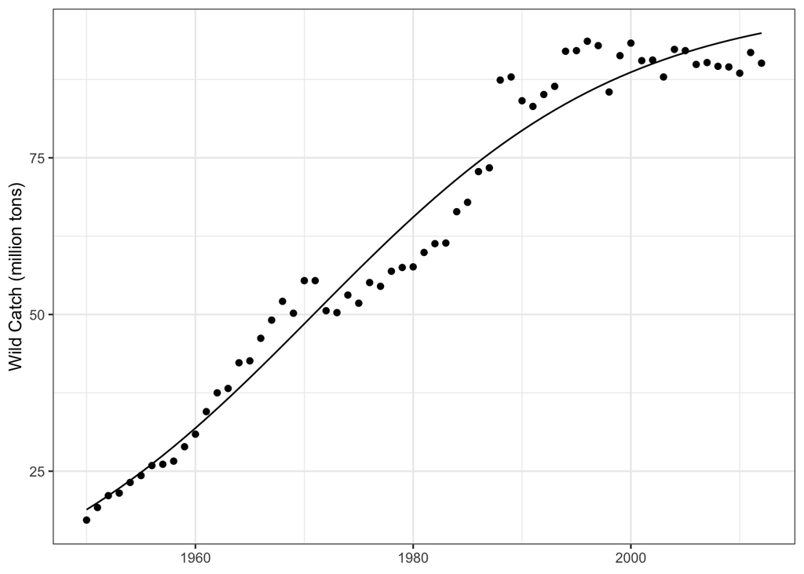

```r
# Make predictions for the population at all of those times (time) in the original df:
catch_predict <- predict(catch_nls)

# Bind predictions to original data frame:
catch_bind <- data.frame(catch_mod, catch_predict) %>%
  mutate(year = year+1950)


# Plot them all together:
ggplot(data = catch_bind, aes(x = year, y = wild_catch_million_tons)) +
  geom_point() +
  geom_line(aes(x = year, y = catch_predict)) +
  theme_bw()+
  labs(y= "Wild Catch (million tons)", x=NULL)
```